# Consequences of covariation

Here I will consider the dynamical consequences of different choices of parameters in our epidemiological model where we explore covariation. Note that this model is the following:
$$\begin{align*}
\frac{dS}{dt} &= (b - b_s N) N - \beta S I - d S \\
\frac{dI}{dt} &= \beta S I - (d + \alpha + \gamma) I \\
\frac{dR}{dt} &= \gamma I - d R \\
N &= S + I + R \\
\beta &= c \frac{s}{h + s}
\end{align*}$$

We consider the consequences of variation and covariation in the contact rate $c$, the shedding rate $s$, the virulence $\alpha$ and the recovery rate $\gamma$. A couple of important quantities that we can calculate analytically include the population size when the disease is absent, $\hat{N_0} = \hat{S_0} = (b - d)/d_s$; the pathogen’s net reproductive rate when invading a fully susceptible population,
$$\begin{equation}
R_0 = \frac{c \frac{s}{h+s} \hat{S_0}}{d + \alpha + \gamma};
\end{equation}$$
and the equilibrium size of the susceptible population at the endemic equilibrium,
$$\begin{equation}
\hat{S_e} = \frac{d + \alpha + \gamma}{c \frac{s}{h+s}}.
\end{equation}$$

Thus, for any particular set of parameters, we can calculate each of these quantitites. The baseline set of parameters is

```r
baselineparams = c(c=.035, shed=.05, h=.15, alpha=.15, gamma=.15, d=.2,
                   sd_c=.035, sd_s=.05, sd_a=.15, sd_g=.15, b=2.5, bs=.01)
```

At this baseline, the size of a fully susceptible population is $\hat{S_0}=$ 230, the baseline net reproductive rate is $R_0=$ 4.025, and the endemic equilibrium susceptible population size is $\hat{S_e}=$ 57.14. We can also look at what these choices imply about the life history of the host population. In particular, $1/d$ is the average lifespan of an uninfected host; for this choice of $d$ that implies a lifespan of 5 time units (we have not specified whether the timescale is in days, weeks, years, etc.). We can compare this to the average duration of an infection, $1/(d +\alpha+\gamma)=$ 2 time units. We can also calculate the probabilities of different outcomes for an infected individual. That is, the probability of recovery is $\gamma/(d+\alpha+\gamma)$, the probability of dying due to disease is $\alpha/(d+\alpha+\gamma)$ and the probability of dying of natural causes is $d/(d+\alpha+\gamma)$. These three probabilities are 0.3, 0.3, and 0.4, respectively. Given these choices, I would say that the disease we are modeling is a fairly slow-progressing disease, but one that has a high probability of death - maybe something like tuberculosis?

We have explored the dynamics of this model using numerical simulation. Importantly, in the simulations that have been run, the starting population size is actually always smaller than the size of a fully susceptible population - we have started with $S = 70$, typically. The consequences of this choice are a bit unclear: it’s possible that it causes the epidemics to end more quickly because the population size is already close to the endemic equilibrium, but it’s equally possible that the epidemics are longer because the susceptible population has a positive growth rate in the absence of an infection. *It is probably worth exploring parameter sets where the starting population size is closer to $\hat{S_0}$ to see what happens in those scenarios.*

In each of the different covariation scenarios, we are comparing three different parameter sets, that produce three different $R_0$ values. Based on the analytical results, we vary parameters that should not impact the effect of variation and covariation on the expected $R_0$.

If there is variation in contact and shedding, the expected $R_0$ is
$$\begin{equation}
E[R_0(c,s)] = R_0\left(\bar{c},\bar{s}\right)\left(1+\frac{h}{\bar{s}\left(h+\bar{s}\right)}\left(\frac{\text{cov}(c,s)}{\bar{c}} - \frac{\sigma_s^2}{h+\bar{s}}\right)\right).
\end{equation}$$
We can calculate the expected $R_0$ given our choices of parameter values

```r
baselineparams = c(c=.035, shed=.05, h=.15, alpha=.15, gamma=.15, d=.2,
                   sd_c=.035, sd_s=.05, sd_a=.15, sd_g=.15, b=2.5, bs=.01) # R0 = 1.225
contact.tau.params1 = c(c=.035, shed=.05, h=.15, alpha=.12, gamma=.05, d=.07,
                        sd_c=.035, sd_s=.05, sd_a=.12, sd_g=.05,b=2.5, bs=.01) # R0 = 2.55
contact.tau.params2 = c(c=.035, shed=.05, h=.15, alpha=.1, gamma=.005, d=.07,
                        sd_c=.035, sd_s=.05, sd_a=.1, sd_g=.005,b=2.5, bs=.01) # R0 = 3.5

## Baseline parameter set
## Covariation is calculated from a specified correlation as cov(x,y)=corr(x,y)*sd(x)*sd(y)
data.frame(baseline=c("The fully susceptible population size",
             "The expected R0, ignoring variation",
             "The expected R0, assuming 0 covariation",
             "The expected R0, assuming positive covariation",
             "The expected R0, assuming negative covariation"),
           value=signif(c(with(as.data.frame(t(baselineparams)), (b-d)/bs),
             with(as.data.frame(t(baselineparams)), c*shed/(h+shed)*(b-d)/bs/(d+alpha+gamma)),
             with(as.data.frame(t(baselineparams)), c*shed/(h+shed)*(b-d)/bs/(d+alpha+gamma) * (1 + h/(shed*(h+shed)) * (0/c - sd_s^2/(h+shed)))),
             with(as.data.frame(t(baselineparams)), c*shed/(h+shed)*(b-d)/bs/(d+alpha+gamma) * (1 + h/(shed*(h+shed)) * ((0.5*sd_c*sd_s)/c - sd_s^2/(h+shed)))),
             with(as.data.frame(t(baselineparams)), c*shed/(h+shed)*(b-d)/bs/(d+alpha+gamma) * (1 + h/(shed*(h+shed)) * ((-0.5*sd_c*sd_s)/c - sd_s^2/(h+shed))))),3))
```

```
##                                         baseline  value
## 1          The fully susceptible population size 230.00
## 2            The expected R0, ignoring variation   4.03
## 3        The expected R0, assuming 0 covariation   3.27
## 4 The expected R0, assuming positive covariation   4.78
## 5 The expected R0, assuming negative covariation   1.76
```

```r
data.frame(params1=c("The fully susceptible population size",
             "The expected R0, ignoring variation",
             "The expected R0, assuming 0 covariation",
             "The expected R0, assuming positive covariation",
             "The expected R0, assuming negative covariation"),
           value=signif(c(with(as.data.frame(t(contact.tau.params1)), (b-d)/bs),
             with(as.data.frame(t(contact.tau.params1)), c*shed/(h+shed)*(b-d)/bs/(d+alpha+gamma)),
             with(as.data.frame(t(contact.tau.params1)), c*shed/(h+shed)*(b-d)/bs/(d+alpha+gamma) * (1 + h/(shed*(h+shed)) * (0/c - sd_s^2/(h+shed)))),
             with(as.data.frame(t(contact.tau.params1)), c*shed/(h+shed)*(b-d)/bs/(d+alpha+gamma) * (1 + h/(shed*(h+shed)) * ((0.5*sd_c*sd_s)/c - sd_s^2/(h+shed)))),
             with(as.data.frame(t(contact.tau.params1)), c*shed/(h+shed)*(b-d)/bs/(d+alpha+gamma) * (1 + h/(shed*(h+shed)) * ((-0.5*sd_c*sd_s)/c - sd_s^2/(h+shed))))),3))
```

```
##                                          params1  value
## 1          The fully susceptible population size 243.00
## 2            The expected R0, ignoring variation   8.86
## 3        The expected R0, assuming 0 covariation   7.20
## 4 The expected R0, assuming positive covariation  10.50
## 5 The expected R0, assuming negative covariation   3.88
```

```r
data.frame(params2=c("The fully susceptible population size",
             "The expected R0, ignoring variation",
             "The expected R0, assuming 0 covariation",
             "The expected R0, assuming positive covariation",
             "The expected R0, assuming negative covariation"),
           value=signif(c(with(as.data.frame(t(contact.tau.params2)), (b-d)/bs),
             with(as.data.frame(t(contact.tau.params2)), c*shed/(h+shed)*(b-d)/bs/(d+alpha+gamma)),
             with(as.data.frame(t(contact.tau.params2)), c*shed/(h+shed)*(b-d)/bs/(d+alpha+gamma) * (1 + h/(shed*(h+shed)) * (0/c - sd_s^2/(h+shed)))),
             with(as.data.frame(t(contact.tau.params2)), c*shed/(h+shed)*(b-d)/bs/(d+alpha+gamma) * (1 + h/(shed*(h+shed)) * ((0.5*sd_c*sd_s)/c - sd_s^2/(h+shed)))),
             with(as.data.frame(t(contact.tau.params2)), c*shed/(h+shed)*(b-d)/bs/(d+alpha+gamma) * (1 + h/(shed*(h+shed)) * ((-0.5*sd_c*sd_s)/c - sd_s^2/(h+shed))))),3))
```

```
##                                          params2  value
## 1          The fully susceptible population size 243.00
## 2            The expected R0, ignoring variation  12.20
## 3        The expected R0, assuming 0 covariation   9.87
## 4 The expected R0, assuming positive covariation  14.40
## 5 The expected R0, assuming negative covariation   5.32
```

If there is variation in contact and virulence, the expected $R_0$ is
$$\begin{equation}
E[R_0(c,\alpha)] = R_0\left(\bar{c},\bar{\alpha}\right)\left(1 + \frac{1}{\bar{\alpha}+\gamma+d}\left(\frac{\sigma_\alpha^2}{\bar{\alpha}+\gamma+d} - \frac{\text{cov}(c,\alpha)}{\bar{c}}\right)\right).
\end{equation}$$
We can calculate the expected $R_0$ given our choices of parameter values

```r
baselineparams = c(c=.035, shed=.05, h=.15, alpha=.15, gamma=.15, d=.2,
                   sd_c=.035, sd_s=.05, sd_a=.15, sd_g=.15, b=2.5, bs=.01)
contact.alpha.params1 = c(c=.035, shed=.22, h=.2, alpha=.1, gamma=.15, d=.2,
                          sd_c=.035, sd_s=.22, sd_a=.12, sd_g=.15, b=2.5, bs=.01)
contact.alpha.params2 = c(c=.035, shed=.22, h=.2, alpha=.1, gamma=.15, d=.2,
                          sd_c=.035, sd_s=.22, sd_a=.12, sd_g=.15, b=2.5, bs=.01)

## Baseline parameter set
## Covariation is calculated from a specified correlation as cov(x,y)=corr(x,y)*sd(x)*sd(y)
data.frame(baseline=c("The fully susceptible population size",
             "The expected R0, ignoring variation",
             "The expected R0, assuming 0 covariation",
             "The expected R0, assuming positive covariation",
             "The expected R0, assuming negative covariation"),
           value=signif(c(with(as.data.frame(t(baselineparams)), (b-d)/bs),
             with(as.data.frame(t(baselineparams)), c*shed/(h+shed)*(b-d)/bs/(d+alpha+gamma)),
             with(as.data.frame(t(baselineparams)), c*shed/(h+shed)*(b-d)/bs/(d+alpha+gamma) * (1 + 1/(alpha+gamma+d) * (sd_a^2/(alpha+gamma+d) - 0/c))),
             with(as.data.frame(t(baselineparams)), c*shed/(h+shed)*(b-d)/bs/(d+alpha+gamma) * (1 + 1/(alpha+gamma+d) * (sd_a^2/(alpha+gamma+d) - 0.5*sd_c*sd_a/c))),
             with(as.data.frame(t(baselineparams)), c*shed/(h+shed)*(b-d)/bs/(d+alpha+gamma) * (1 + 1/(alpha+gamma+d) * (sd_a^2/(alpha+gamma+d) + 0.5*sd_c*sd_a/c)))),3))
```

```
##                                         baseline  value
## 1          The fully susceptible population size 230.00
## 2            The expected R0, ignoring variation   4.03
## 3        The expected R0, assuming 0 covariation   4.39
## 4 The expected R0, assuming positive covariation   3.78
## 5 The expected R0, assuming negative covariation   4.99
```

```r
data.frame(params1=c("The fully susceptible population size",
             "The expected R0, ignoring variation",
             "The expected R0, assuming 0 covariation",
             "The expected R0, assuming positive covariation",
             "The expected R0, assuming negative covariation"),
           value=signif(c(with(as.data.frame(t(contact.alpha.params1)), (b-d)/bs),
             with(as.data.frame(t(contact.alpha.params1)), c*shed/(h+shed)*(b-d)/bs/(d+alpha+gamma)),
             with(as.data.frame(t(contact.alpha.params1)), c*shed/(h+shed)*(b-d)/bs/(d+alpha+gamma) * (1 + 1/(alpha+gamma+d) * (sd_a^2/(alpha+gamma+d) - 0/c))),
             with(as.data.frame(t(contact.alpha.params1)), c*shed/(h+shed)*(b-d)/bs/(d+alpha+gamma) * (1 + 1/(alpha+gamma+d) * (sd_a^2/(alpha+gamma+d) - 0.5*sd_c*sd_a/c))),
             with(as.data.frame(t(contact.alpha.params1)), c*shed/(h+shed)*(b-d)/bs/(d+alpha+gamma) * (1 + 1/(alpha+gamma+d) * (sd_a^2/(alpha+gamma+d) + 0.5*sd_c*sd_a/c)))),3))
```

```
##                                          params1  value
## 1          The fully susceptible population size 230.00
## 2            The expected R0, ignoring variation   9.37
## 3        The expected R0, assuming 0 covariation  10.00
## 4 The expected R0, assuming positive covariation   8.79
## 5 The expected R0, assuming negative covariation  11.30
```

There are a couple of issues here: the parameter sd_a is not constant across these simulations, meaning that the variation changes from the baseline and the second and third parameter sets are identical.

If there is variation in shedding and virulence, the expected $R_0$ is
$$\begin{equation}
E[R_0(s,\alpha)] = R_0\left(\bar{s},\bar{\alpha}\right) \left(1 - \frac{h}{\bar{s}\left(h+\bar{s}\right)^2}\sigma_s^2 - \frac{h}{\bar{s}\left(h+\bar{s}\right)\left(\bar{\alpha}+\gamma+d\right)}\text{cov}(s,\alpha) + \frac{1}{\left(\bar{\alpha}+\gamma+d\right)^2}\sigma_\alpha^2\right).
\end{equation}$$
We can calculate the expected $R_0$ given our choices of parameter values

```r
baselineparams = c(c=.035, shed=.05, h=.15, alpha=.15, gamma=.15, d=.2,
                   sd_c=.035, sd_s=.05, sd_a=.15, sd_g=.15, b=2.5, bs=.01)
tau.alpha.params1 = c(c=.074, shed=.05, h=.15, alpha=.15, gamma=.15, d=.2,
                      sd_c=.074, sd_s=.05, sd_a=.15, sd_g=.15, b=2.5, bs=.01)
tau.alpha.params2 = c(c=.1, shed=.05, h=.15, alpha=.15, gamma=.15, d=.2,
                      sd_c=.074, sd_s=.05, sd_a=.15, sd_g=.15, b=2.5, bs=.01)

## Baseline parameter set
## Covariation is calculated from a specified correlation as cov(x,y)=corr(x,y)*sd(x)*sd(y)
data.frame(baseline=c("The fully susceptible population size",
             "The expected R0, ignoring variation",
             "The expected R0, assuming 0 covariation",
             "The expected R0, assuming positive covariation",
             "The expected R0, assuming negative covariation"),
           value=signif(c(with(as.data.frame(t(baselineparams)), (b-d)/bs),
             with(as.data.frame(t(baselineparams)), c*shed/(h+shed)*(b-d)/bs/(d+alpha+gamma)),
             with(as.data.frame(t(baselineparams)), c*shed/(h+shed)*(b-d)/bs/(d+alpha+gamma) * (1 - h/(shed*(h+shed)^2)*sd_s^2 - h/(shed*(h+shed)*(alpha+gamma+d))*0 + 1/(alpha+gamma+d)^2*sd_a^2)),
             with(as.data.frame(t(baselineparams)), c*shed/(h+shed)*(b-d)/bs/(d+alpha+gamma) * (1 - h/(shed*(h+shed)^2)*sd_s^2 - h/(shed*(h+shed)*(alpha+gamma+d))*0.5*sd_s*sd_a + 1/(alpha+gamma+d)^2*sd_a^2)),
             with(as.data.frame(t(baselineparams)), c*shed/(h+shed)*(b-d)/bs/(d+alpha+gamma) * (1 - h/(shed*(h+shed)^2)*sd_s^2 + h/(shed*(h+shed)*(alpha+gamma+d))*0.5*sd_s*sd_a + 1/(alpha+gamma+d)^2*sd_a^2))),3))
```

```
##                                         baseline  value
## 1          The fully susceptible population size 230.00
## 2            The expected R0, ignoring variation   4.03
## 3        The expected R0, assuming 0 covariation   3.63
## 4 The expected R0, assuming positive covariation   3.18
## 5 The expected R0, assuming negative covariation   4.09
```

```r
data.frame(params1=c("The fully susceptible population size",
             "The expected R0, ignoring variation",
             "The expected R0, assuming 0 covariation",
             "The expected R0, assuming positive covariation",
             "The expected R0, assuming negative covariation"),
           value=signif(c(with(as.data.frame(t(tau.alpha.params1)), (b-d)/bs),
             with(as.data.frame(t(tau.alpha.params1)), c*shed/(h+shed)*(b-d)/bs/(d+alpha+gamma)),
             with(as.data.frame(t(tau.alpha.params1)), c*shed/(h+shed)*(b-d)/bs/(d+alpha+gamma) * (1 - h/(shed*(h+shed)^2)*sd_s^2 - h/(shed*(h+shed)*(alpha+gamma+d))*0 + 1/(alpha+gamma+d)^2*sd_a^2)),
             with(as.data.frame(t(tau.alpha.params1)), c*shed/(h+shed)*(b-d)/bs/(d+alpha+gamma) * (1 - h/(shed*(h+shed)^2)*sd_s^2 - h/(shed*(h+shed)*(alpha+gamma+d))*0.5*sd_s*sd_a + 1/(alpha+gamma+d)^2*sd_a^2)),
             with(as.data.frame(t(tau.alpha.params1)), c*shed/(h+shed)*(b-d)/bs/(d+alpha+gamma) * (1 - h/(shed*(h+shed)^2)*sd_s^2 + h/(shed*(h+shed)*(alpha+gamma+d))*0.5*sd_s*sd_a + 1/(alpha+gamma+d)^2*sd_a^2))),3))
```

```
##                                          params1  value
## 1          The fully susceptible population size 230.00
## 2            The expected R0, ignoring variation   8.51
## 3        The expected R0, assuming 0 covariation   7.68
## 4 The expected R0, assuming positive covariation   6.72
## 5 The expected R0, assuming negative covariation   8.64
```

```r
data.frame(params2=c("The fully susceptible population size",
             "The expected R0, ignoring variation",
             "The expected R0, assuming 0 covariation",
             "The expected R0, assuming positive covariation",
             "The expected R0, assuming negative covariation"),
           value=signif(c(with(as.data.frame(t(tau.alpha.params2)), (b-d)/bs),
             with(as.data.frame(t(tau.alpha.params2)), c*shed/(h+shed)*(b-d)/bs/(d+alpha+gamma)),
             with(as.data.frame(t(tau.alpha.params2)), c*shed/(h+shed)*(b-d)/bs/(d+alpha+gamma) * (1 - h/(shed*(h+shed)^2)*sd_s^2 - h/(shed*(h+shed)*(alpha+gamma+d))*0 + 1/(alpha+gamma+d)^2*sd_a^2)),
             with(as.data.frame(t(tau.alpha.params2)), c*shed/(h+shed)*(b-d)/bs/(d+alpha+gamma) * (1 - h/(shed*(h+shed)^2)*sd_s^2 - h/(shed*(h+shed)*(alpha+gamma+d))*0.5*sd_s*sd_a + 1/(alpha+gamma+d)^2*sd_a^2)),
             with(as.data.frame(t(tau.alpha.params2)), c*shed/(h+shed)*(b-d)/bs/(d+alpha+gamma) * (1 - h/(shed*(h+shed)^2)*sd_s^2 + h/(shed*(h+shed)*(alpha+gamma+d))*0.5*sd_s*sd_a + 1/(alpha+gamma+d)^2*sd_a^2))),3))
```

```
##                                          params2  value
## 1          The fully susceptible population size 230.00
## 2            The expected R0, ignoring variation  11.50
## 3        The expected R0, assuming 0 covariation  10.40
## 4 The expected R0, assuming positive covariation   9.09
## 5 The expected R0, assuming negative covariation  11.70
```

# Lexi: read only from here to the bottom

To make the comparison with the numerical simulations easier, we can also do similar calculations but for the endemic number of susceptible hosts (which removes any dependence on initial conditions, since the $R_0$ calculations above assume that you are starting at $\hat{S_0$}, whereas the numerical simulations assumed a starting point of $S=70$). Given that
$$\begin{equation}
S_e = \frac{d + \alpha + \gamma}{c \frac{s}{h+s}},
\end{equation}$$
then the effect of variation in $c$ is
$$\begin{equation}
E[S_e(c)] = S_e(\hat{c}) \left(1 + \frac{1}{\hat{c}^2} \sigma_c^2\right);
\end{equation}$$
the effect of variation in $s$ is
$$\begin{equation}
E[S_e(s)] = S_e(\hat{s}) \left(1 + \frac{h}{\hat{s}^2(h+\hat{s})} \sigma_s^2\right);
\end{equation}$$
and the effect of variation in $\alpha$ is
$$\begin{equation}
E[S_e(\alpha)] = S_e(\hat{\alpha}).
\end{equation}$$
In other words, variation in contact or shedding is expected to increase the expected number of susceptible hosts at equilibrium, where variation in virulence will not affect the expected number of susceptible hosts.

The effect of covariation in $c$ and $s$ will produce an expected endemic equilibrium of
$$\begin{equation}
E[S_e(c,s)] = S_e\left(\hat{c},\hat{s}\right) \left(1 + \frac{1}{\hat{c}^2} \sigma_c^2 + \frac{h}{h\hat{c}\hat{s}+\hat{c}\hat{s}^2} \text{cov}(c,s) + \frac{h}{\hat{s}^2(h+\hat{s})} \sigma_s^2\right)
\end{equation}$$

The effect of covariation in $c$ and $\alpha$ will produce an expected endemic equilbrium of
$$\begin{equation}
E[S_e(c,\alpha)] = S_e\left(\hat{c},\hat{\alpha}\right) \left(1 + \frac{1}{\hat{c}^2} \sigma_c^2 - \frac{1}{\hat{c}(\hat{\alpha}+\gamma+d)} \text{cov}(c,\alpha)\right)
\end{equation}$$

The effect of covariation in $s$ and $\alpha$ will produce an expected endemic equilibrium of
$$\begin{equation}
E[S_e(s,\alpha)] = S_e\left(\hat{s},\hat{\alpha}\right) \left(1 + \frac{h}{\hat{s}^2(h+\hat{s})}\sigma_s^2 - \frac{h}{\hat{s}(h+\hat{s})(\hat{\alpha}+\gamma+d)}\text{cov}(s,\alpha)\right)
\end{equation}$$

From this, you can see that positive covariation between contact and shedding, negative covariation between contact and virulence, or negative covariation between shedding and virulence will each increase the endemic equilibrium; covariation of the opposite sign may decrease the endemic equilibrium if it is large enough to offset the positive effects of variation in contact or shedding.

We can look at these for each of the parameter sets, and compare the analytical expectation (given the parameter values) with the results of the numerical simulations.

#### Effect of covariation in contact and shedding on the endemic susceptible population size

Here are the analytical predictions:
$$\begin{equation}
E[S_e(c,s)] = S_e\left(\hat{c},\hat{s}\right) \left(1 + \frac{1}{\hat{c}^2} \sigma_c^2 + \frac{h}{h\hat{c}\hat{s}+\hat{c}\hat{s}^2} \text{cov}(c,s) + \frac{h}{\hat{s}^2(h+\hat{s})} \sigma_s^2\right)
\end{equation}$$

And here are the numerical results for different covariance scenarios:

```
##                                         baseline value
## 1            The expected Se, ignoring variation  57.1
## 2        The expected Se, assuming 0 covariation 157.0
## 3 The expected Se, assuming positive covariation 179.0
## 4 The expected Se, assuming negative covariation 136.0
```

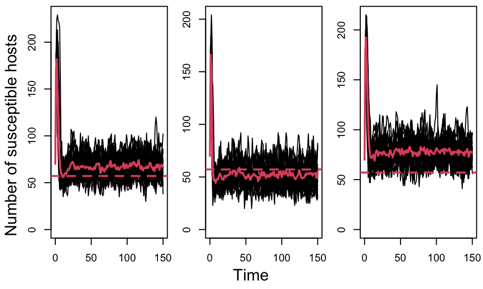

The effect of covariation between contact and shedding at low R0 values. Moving from left to right, the panels show the results for zero covariance, positive covariance, and negative covariance. The dashed red line shows the expected population size in the absence of any variation.

```
##                                          params1 value
## 1            The expected Se, ignoring variation  27.4
## 2        The expected Se, assuming 0 covariation  75.4
## 3 The expected Se, assuming positive covariation  85.7
## 4 The expected Se, assuming negative covariation  65.1
```

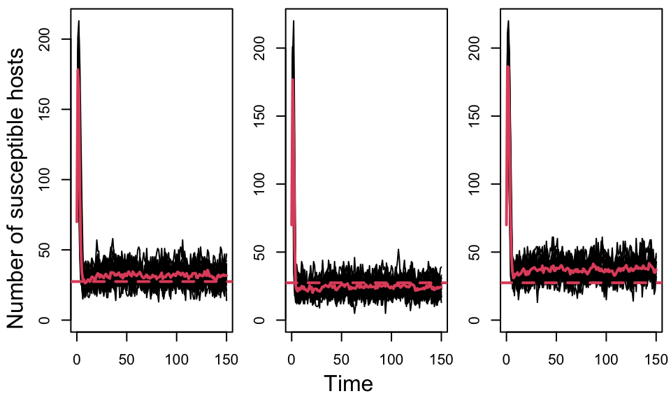

The effect of covariation between contact and shedding at moderate R0 values. Moving from left to right, the panels show the results for zero covariance, positive covariance, and negative covariance. The dashed red line shows the expected population size in the absence of any variation.

```
##                                          params2 value
## 1            The expected Se, ignoring variation  20.0
## 2        The expected Se, assuming 0 covariation  55.0
## 3 The expected Se, assuming positive covariation  62.5
## 4 The expected Se, assuming negative covariation  47.5
```

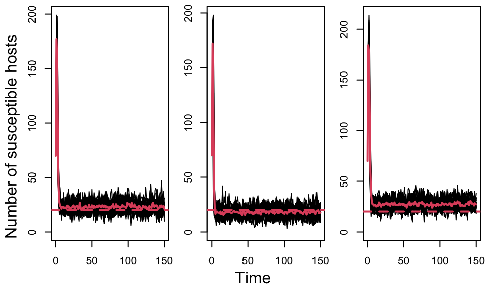

The effect of covariation between contact and shedding at high R0 values. Moving from left to right, the panels show the results for zero covariance, positive covariance, and negative covariance. The dashed red line shows the expected population size in the absence of any variation.

Interestingly, we are not seeing the results we expected. In fact, the results are not even *close* to what we expected. The effect of variation is much smaller than anticipated (although it is in the right direction), and it is negative, rather than positive, covariation that increases the number of susceptible hosts. This is all wrong.

#### Effect of covariation in contact and virulence on the endemic susceptible population size

Here are the analytical predictions:
$$\begin{equation}
E[S_e(c,\alpha)] = S_e\left(\hat{c},\hat{\alpha}\right) \left(1 + \frac{1}{\hat{c}^2} \sigma_c^2 - \frac{1}{\hat{c}(\hat{\alpha}+\gamma+d)} \text{cov}(c,\alpha)\right)
\end{equation}$$

And here are the numerical results for different covariance scenarios:

```
##                                         baseline value
## 1            The expected Se, ignoring variation  57.1
## 2        The expected Se, assuming 0 covariation 114.0
## 3 The expected Se, assuming positive covariation 106.0
## 4 The expected Se, assuming negative covariation 123.0
```

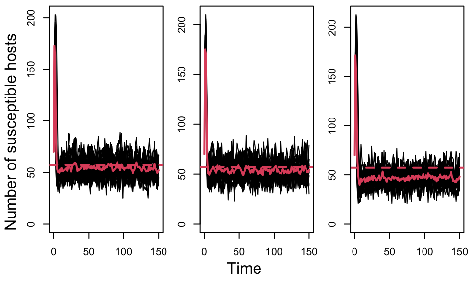

The effect of covariation between contact and virulence at low R0 values. Moving from left to right, the panels show the results for zero covariance, positive covariance, and negative covariance. The dashed red line shows the expected population size in the absence of any variation.

```
##                                          params1 value
## 1            The expected Se, ignoring variation  24.5
## 2        The expected Se, assuming 0 covariation  49.1
## 3 The expected Se, assuming positive covariation  45.8
## 4 The expected Se, assuming negative covariation  52.4
```

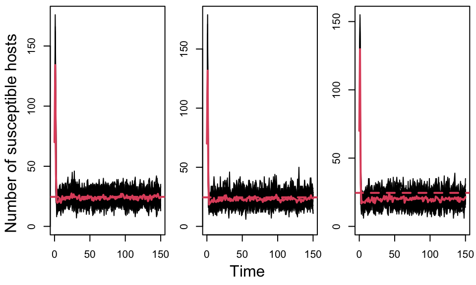

**Again**, we see that the results are all wrong. The effect of variation is essentially zero, rather than being large, and positive covariation has essentially no effect whereas negative covariation has a negative effect on $\hat{S_e}$ rather than a positive effect.

#### Effect of covariation in shedding and virulence on the endemic susceptible population size

Here are the analytical predictions:
$$\begin{equation}
E[S_e(s,\alpha)] = S_e\left(\hat{s},\hat{\alpha}\right) \left(1 + \frac{h}{\hat{s}^2(h+\hat{s})}\sigma_s^2 - \frac{h}{\hat{s}(h+\hat{s})(\hat{\alpha}+\gamma+d)}\text{cov}(s,\alpha)\right)
\end{equation}$$

And here are the numerical results for different covariance scenarios:

```
##                                         baseline value
## 1            The expected Se, ignoring variation  57.1
## 2        The expected Se, assuming 0 covariation 100.0
## 3 The expected Se, assuming positive covariation  93.6
## 4 The expected Se, assuming negative covariation 106.0
```

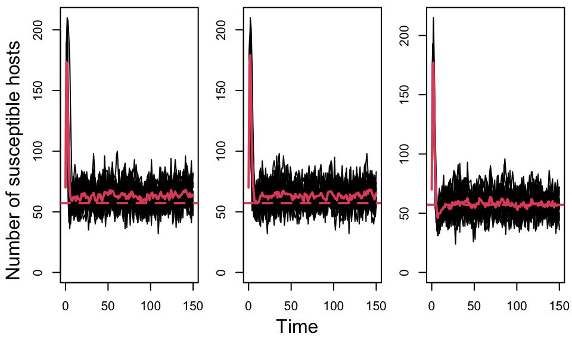

The effect of covariation between shedding and virulence at low R0 values. Moving from left to right, the panels show the results for zero covariance, positive covariance, and negative covariance. The dashed red line shows the expected population size in the absence of any variation.

```
##                                          params1 value
## 1            The expected Se, ignoring variation  27.0
## 2        The expected Se, assuming 0 covariation  47.3
## 3 The expected Se, assuming positive covariation  44.3
## 4 The expected Se, assuming negative covariation  50.3
```

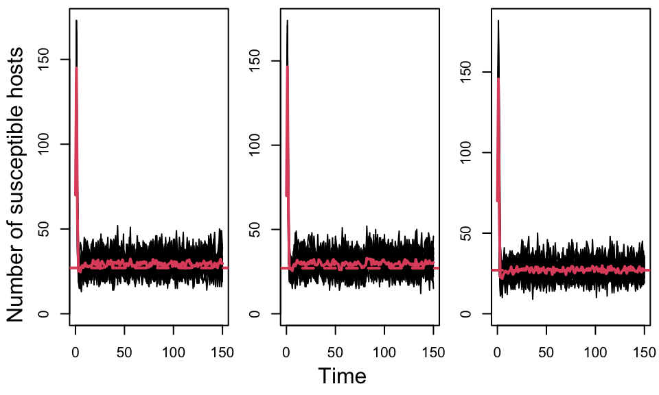

The effect of covariation between shedding and virulence at moderate R0 values. Moving from left to right, the panels show the results for zero covariance, positive covariance, and negative covariance. The dashed red line shows the expected population size in the absence of any variation.

```
##                                          params2 value
## 1            The expected Se, ignoring variation  20.0
## 2        The expected Se, assuming 0 covariation  35.0
## 3 The expected Se, assuming positive covariation  32.7
## 4 The expected Se, assuming negative covariation  37.2
```

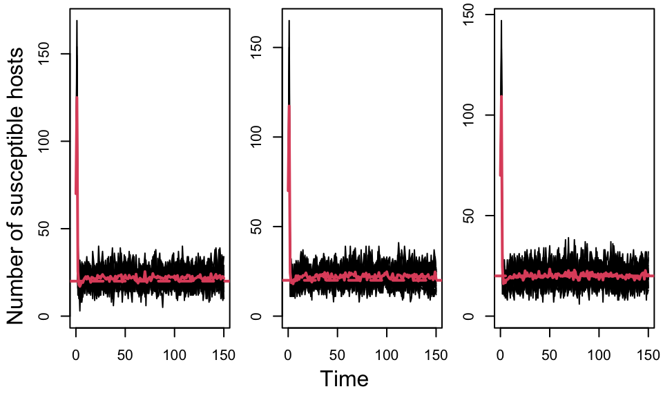

The effect of covariation between shedding and virulence at high R0 values. Moving from left to right, the panels show the results for zero covariance, positive covariance, and negative covariance. The dashed red line shows the expected population size in the absence of any variation.

#### Figuring things out

These results seem all wrong - the effects are often in the totally wrong direction from the prediction. I’m not sure why, so let’s dive into the simulation code to try to figure it out. Let’s start with the case where there is positive covariation between contact and shedding.

```r
pick_individuals_multivariate <-function(N, traitmeans, traitsds, corr){
  ## Generate Lognormal random variables with zeros.
  ## traitmeans - Vector of mean trait values
  ## traitsds - Vector of trait standard deviations
  ## R - Correlation matrix - should have 1s along the diagonal and off-diagonal elements reflecting correlations between different variables

  ## Number of traits
  p <- length(traitmeans);
  mu <- matrix(0,p,1);
  sigma <- matrix(0,p,p);
  for (i in 1:p) {
    mu[i] = log(traitmeans[i]^2 / sqrt(traitsds[i]^2+traitmeans[i]^2))
    sigma[i,i] = log(1 + traitsds[i]^2/traitmeans[i]^2);
  }

  Cov <- sqrt(sigma)%*%corr%*%sqrt(sigma);
  X <- matrix(rnorm(p*N,0,1), nrow = N, ncol = p);
  for (i in 1:N){
    X[i,] <- exp(mu + chol(Cov)%*%X[i,])
  }
  return(X);
}


baselineparams = c(c=.035, shed=.05, h=.15, alpha=.15, gamma=.15, d=.2,
                   sd_c=.035, sd_s=.05, sd_a=.15, sd_g=.15, b=2.5, bs=.01) # R0 = 1.225
nocorr <- matrix(c(1,0,0,1), nrow=2, byrow=T)
negcorr <- matrix(c(1,-.5,-.5,1), nrow=2, byrow=T)
poscorr <- matrix(c(1,.5,.5,1), nrow=2, byrow=T)

## generate a bunch of individuals and make sure the correlations are done correctly
n0 <- pick_individuals_multivariate(1000, baselineparams[c('c','shed')], baselineparams[c('sd_c','sd_s')],corr=nocorr)
n1 <- pick_individuals_multivariate(1000, baselineparams[c('c','shed')], baselineparams[c('sd_c','sd_s')],corr=poscorr)
n2 <- pick_individuals_multivariate(1000, baselineparams[c('c','shed')], baselineparams[c('sd_c','sd_s')],corr=negcorr)

## slopes are all pointing in the right direction, so it seems like the the individuals are being created correctly
summary(lm(n0[,2]~n0[,1]))
```

```
##
## Call:
## lm(formula = n0[, 2] ~ n0[, 1])
##
## Residuals:
##      Min       1Q   Median       3Q      Max
## -0.04465 -0.02768 -0.01278  0.01146  0.32540
##
## Coefficients:
##              Estimate Std. Error t value Pr(>|t|)
## (Intercept)  0.047245   0.002078  22.736   <2e-16 ***
## n0[, 1]     -0.013870   0.045427  -0.305     0.76
## ---
## Signif. codes:  0 '***' 0.001 '**' 0.01 '*' 0.05 '.' 0.1 ' ' 1
##
## Residual standard error: 0.04409 on 998 degrees of freedom
## Multiple R-squared:  9.34e-05,   Adjusted R-squared:  -0.0009085
## F-statistic: 0.09322 on 1 and 998 DF,  p-value: 0.7602
```

```r
summary(lm(n1[,2]~n1[,1]))
```

```
##
## Call:
## lm(formula = n1[, 2] ~ n1[, 1])
##
## Residuals:
##      Min       1Q   Median       3Q      Max
## -0.07934 -0.02036 -0.00838  0.00941  0.44967
##
## Coefficients:
##             Estimate Std. Error t value Pr(>|t|)
## (Intercept) 0.033022   0.001562   21.14   <2e-16 ***
## n1[, 1]     0.321245   0.027540   11.66   <2e-16 ***
## ---
## Signif. codes:  0 '***' 0.001 '**' 0.01 '*' 0.05 '.' 0.1 ' ' 1
##
## Residual standard error: 0.03597 on 998 degrees of freedom
## Multiple R-squared:   0.12,  Adjusted R-squared:  0.1191
## F-statistic: 136.1 on 1 and 998 DF,  p-value: < 2.2e-16
```

```r
summary(lm(n2[,2]~n2[,1]))
```

```
##
## Call:
## lm(formula = n2[, 2] ~ n2[, 1])
##
## Residuals:
##      Min       1Q   Median       3Q      Max
## -0.04725 -0.02360 -0.01097  0.01132  0.21339
##
## Coefficients:
##              Estimate Std. Error t value Pr(>|t|)
## (Intercept)  0.056846   0.001551  36.649   <2e-16 ***
## n2[, 1]     -0.248356   0.027424  -9.056   <2e-16 ***
## ---
## Signif. codes:  0 '***' 0.001 '**' 0.01 '*' 0.05 '.' 0.1 ' ' 1
##
## Residual standard error: 0.03678 on 998 degrees of freedom
## Multiple R-squared:  0.07594,    Adjusted R-squared:  0.07501
## F-statistic: 82.01 on 1 and 998 DF,  p-value: < 2.2e-16
```